# Compute integrated POC fluxes at 100 m and 1000 m

Author

Thelma Panaïotis

```r
source("utils.R")
```

# Wang 2023

## Read data

Start by reading model output from Wang 2023.

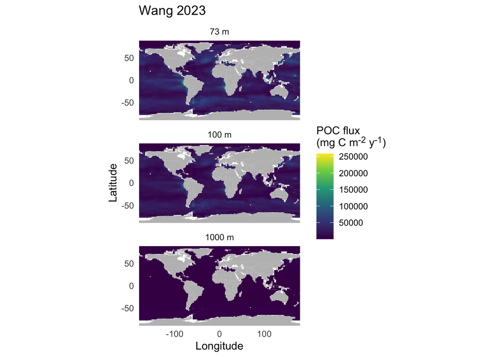

```r
mat_wang <- readMat("data/raw/Cexp_CAFE_kl24h.mat")$EXP
# Define target fields and corresponding depths
targets <- c("POCexp", "POC100", "POC1000")
depths <- c("POCexp" = 73, "POC100" = 100, "POC1000" = 1000)
# Read lon and lat values from Wang paper https://static-content.springer.com/esm/art%3A10.1038%2Fs41586-023-06772-4/MediaObjects/41586_2023_6772_MOESM7_ESM.xlsx
lon_lat <- read_excel("data/raw/41586_2023_6772_MOESM2_ESM.xlsx", col_types = c("numeric", "numeric", "skip"))
lat_values <- lon_lat %>% distinct(lat) %>% pull()
lon_values <- lon_lat %>% distinct(lon) %>% pull()

# Process each target field
df_wang_2023 <- map_dfr(targets, function(targ) {

  # Extract the relevant matrix for the target
  d <- mat_wang[,,1][[targ]]

  # Convert matrix to dataframe with lat and lon as rownames and colnames
  df <- as.data.frame(d) %>%
    rownames_to_column(var = "lat") %>%
    setNames(c("lat", lon_values)) %>%
    pivot_longer(cols = -lat, names_to = "lon", values_to = "poc_flux") %>%
    mutate(
      # Convert lat and lon to numeric
      lat = as.numeric(lat_values[as.numeric(lat)]),
      lon = as.numeric(lon),

      # Recenter longitude over the Atlantic Ocean
      lon = ifelse(lon > 180, lon - 360, lon),

      # Assign depth and apply the flux conversion
      depth = depths[targ],
      poc_flux = na_if(poc_flux, 0),  # Convert 0 to NA ,
      poc_flux = poc_flux * 12,  # Convert POC flux from mmol m⁻² y⁻¹ to mg C m⁻² y⁻¹

      # Add model name
      model = "Wang 2023"
    )

  return(df)
}) %>%
  select(lon, lat, depth, poc_flux, model) # Reorganize the final columns

# Plot map
ggplot(df_wang_2023) +
  geom_raster(aes(x = lon, y = lat, fill = poc_flux)) +
  geom_polygon(data = world, aes(x = lon, y = lat, group = group), fill = "grey") +
  scale_fill_viridis_c(na.value = NA) +
  labs(
    x = "Longitude", y = "Latitude",
    fill = "POC flux<br>(mg C m<sup>-2</sup> y<sup>-1</sup>)"
  ) +
  ggtitle("Wang 2023") +
  coord_quickmap(expand = 0) +
  facet_wrap(~depth, ncol = 1, labeller = labeller(depth = function(x) paste0(x, " m"))) +
  theme(legend.title = element_markdown())
```

## Compute pixel area

with $lat_{N}$ and $lat_{S}$ the northern and southern latitude borders of the pixel.

Let’s adapt this to the Wang 2023 coordinates grid.

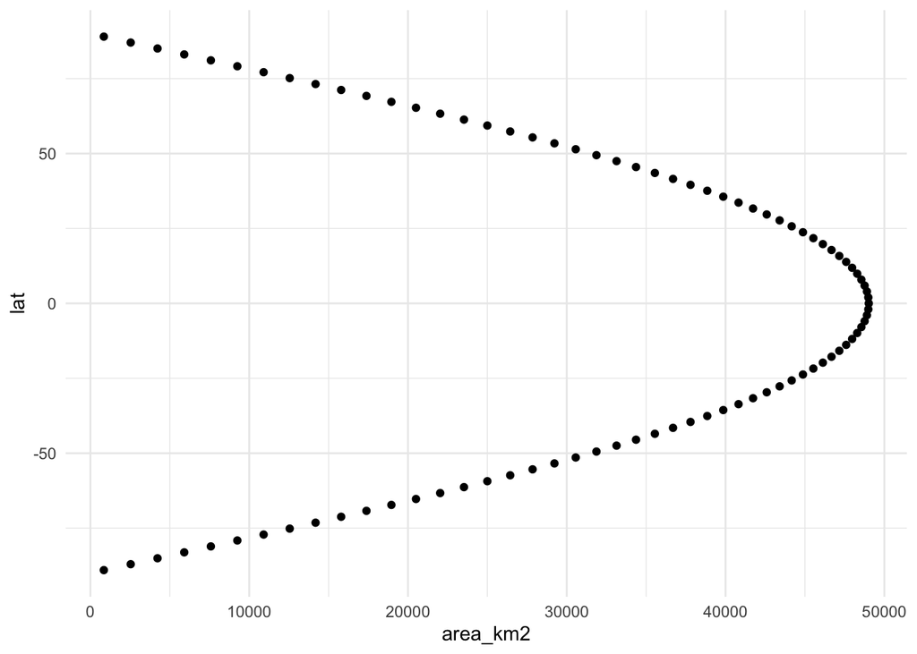

```r
# Given lat values are the middle of each pixel, use these to compute northern and southern border of each pixels
pix_area <- df_wang_2023 %>%
  select(lat) %>% # keep only lat
  distinct() %>%  # keep only unique values
  arrange(desc(lat)) %>% # arrange by decreasing latitude
  mutate(
    lag_lat = lag(lat), # get adjacent (north) pixel
    diff = lag_lat - lat, # difference between the centers of two adjacent pixels
    diff = ifelse(is.na(diff), median(diff, na.rm = TRUE), diff) # replace by median value if not computed
  ) %>%
  mutate(
    lat1 = (lat + (diff / 2)) * pi / 180, # upper border
    lat2 = (lat - (diff / 2)) * pi / 180, # lower border
    area_m2 = ((pi/180)*(R)^2 * abs(sin(lat1) - sin(lat2)))*10^6 * 2, # area in m² # *2 at the end because these are 2° pixels in longitude
    area_km2 = area_m2 / 1e6, # area in km²
  )

# Plot computed area VS latitude
ggplot(pix_area) +
  geom_point(aes(x = area_km2, y = lat))
```

```r
# Seems OK!
```

One degree of latitude is ≈ 111 km, same for longitude around the equator. For a 2° × 2° pixel, we thus expect a surface area of 222 × 222 = 49284 km² around the equator.

## Compute integrated flux

Now let’s multiply the flux in each pixel by the area of the pixel and sum it by layer to obtain total fluxes.

```r
# Then we can join pixel area to POC flux and compute POC flux × area
df_wang_2023 <- df_wang_2023 %>%
  left_join(pix_area %>% select(lat, area_m2, area_km2), by = join_by(lat)) %>%
  mutate(poc_flux_2 = poc_flux * area_m2)

# Compute total POC flux for each layer
res_wang_2023 <- df_wang_2023 %>%
  group_by(depth) %>%
  summarise(
    tot_poc_flux_mg = sum(poc_flux_2, na.rm = TRUE),
    tot_poc_flux_pg = tot_poc_flux_mg * 10^(-18)
  )
res_wang_2023
```

```
# A tibble: 3 × 3
  depth tot_poc_flux_mg tot_poc_flux_pg
  <dbl>           <dbl>           <dbl>
1    73         1.08e19          10.8
2   100         7.37e18           7.37
3  1000         5.84e17           0.584
```

Computed fluxes are:

- **10.8 Pg C y⁻¹ at 73 m**
- **7.4 Pg C y⁻¹ at 100 m**
- **0.6 Pg C y⁻¹ at 1000 m**

In their paper, Wang 2023 give the value of **10.63 Pg C y⁻¹ at 73 m**.

# DeVries and Weber 2022

## Read data

This is the SIMPLE-TRIM model from RECCAP2.

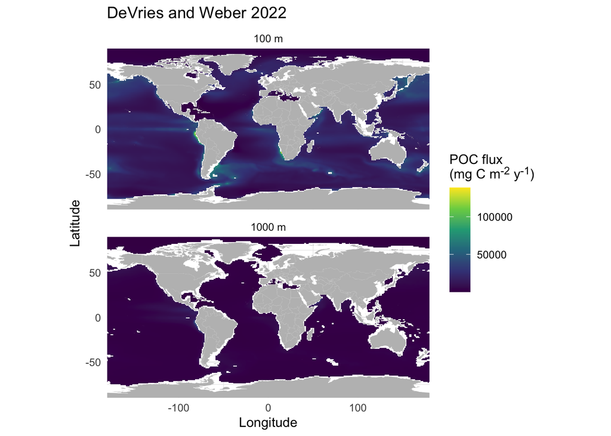

```r
# Name of model is SIMPLE-TRIM

## Read model output
arr_100 <- readMat("data/raw/all_models_POC_flux_100.mat")$all.models.POC.flux.100 # 100 m
arr_1000 <- readMat("data/raw/all_models_POC_flux_1000.mat")$all.models.POC.flux.1000 # 1000 m

lon_values <- seq(0.5, 359.5)
lat_values <- seq(-89.5, 89.5)

# Convert the matrix to a tibble, add lon, lat and convert POC flux
# 100 m
mat <- t(arr_100[, , 12]) # SIMPLE-TRIM is model n°12 in the list at 100 m
df_100 <- as_tibble(as.vector(mat), .name_repair = "minimal") %>%
  mutate(
    lon = rep(lon_values, length.out = n()), # use provided longitude values
    lat = rep(lat_values, each = length(lon_values)), # lat values are always the same
    lon = ifelse(lon > 180, lon - 360, lon), # fix longitude values > 180
    depth = 100
  ) %>%
  rename(poc_flux = value) %>%
  mutate(poc_flux = poc_flux * 1000 * 12)  # Convert POC flux from mol C m⁻² y⁻¹ to mg C m⁻² y⁻¹)

# 1000 m
mat <- t(arr_1000[, , 7]) # SIMPLE-TRIM is model n°7 in the list at 1000 m
df_1000 <- as_tibble(as.vector(mat), .name_repair = "minimal") %>%
  mutate(
    lon = rep(lon_values, length.out = n()), # use provided longitude values
    lat = rep(lat_values, each = length(lon_values)), # lat values are always the same
    lon = ifelse(lon > 180, lon - 360, lon), # fix longitude values > 180
    depth = 1000
  ) %>%
  rename(poc_flux = value) %>%
  mutate(poc_flux = poc_flux * 1000 * 12)  # Convert POC flux from mol C m⁻² y⁻¹ to mg C m⁻² y⁻¹)

# Join together data at 100 and 1000 m
df_dev_2022 <- bind_rows(df_100, df_1000)

ggplot(df_dev_2022) +
  geom_raster(aes(x = lon, y = lat, fill = poc_flux)) +
  geom_polygon(data = world, aes(x = lon, y = lat, group = group), fill = "grey") +
  scale_fill_viridis_c(na.value = NA) +
  labs(
    x = "Longitude", y = "Latitude",
    fill = "POC flux<br>(mg C m<sup>-2</sup> y<sup>-1</sup>)"
  ) +
  coord_quickmap(expand = 0) +
  facet_wrap(~depth, ncol = 1, labeller = labeller(depth = function(x) paste0(x, " m"))) +
  ggtitle("DeVries and Weber 2022") +
  theme(legend.title = element_markdown())
```

## Compute pixel area

Here we have a regular grid of 1°×1°. Max area expected is 111 × 111 = 12321 km².

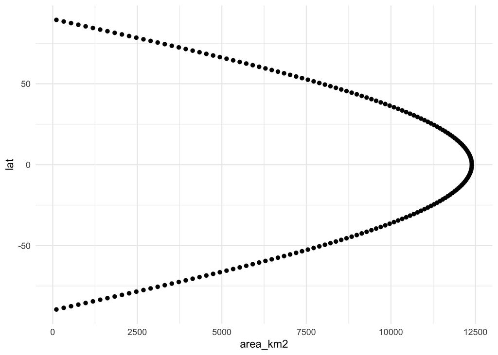

```r
## Compute surface of each pixel
pix_area <- df_dev_2022 %>%
  select(lat) %>%
  distinct() %>%
  arrange(desc(lat)) %>%
  mutate(
    lat1 = (lat + 0.5) * pi / 180, # upper border
    lat2 = (lat - 0.5) * pi / 180, # lower border
    area_m2 = ((pi/180)*(R)^2 * abs(sin(lat1) - sin(lat2)))*10^6 , # area in m²
    area_km2 = area_m2 / 1e6, # area in km²
  )
ggplot(pix_area) + geom_point(aes(x = area_km2, y = lat))
```

```r
# OK
```

## Compute integrated flux

```r
## Compute integrated POC flux
df_dev_2022 <- df_dev_2022 %>%
  left_join(pix_area %>% select(lat, area_m2, area_km2), by = join_by(lat)) %>%
  mutate(poc_flux_2 = poc_flux * area_m2)

# Group and sum by layer
res_dev_2022 <- df_dev_2022 %>%
  group_by(depth) %>%
  summarise(
    tot_poc_flux_mg = sum(poc_flux_2, na.rm = TRUE),
    tot_poc_flux_pg = tot_poc_flux_mg * 10^(-18)
  )
res_dev_2022
```

```
# A tibble: 2 × 3
  depth tot_poc_flux_mg tot_poc_flux_pg
  <dbl>           <dbl>           <dbl>
1   100         6.13e18           6.13
2  1000         8.52e17           0.852
```

Computed fluxes are:

- **6.1 Pg C y⁻¹ at 100 m**
- **0.9 Pg C y⁻¹ at 1000 m**

# Nowicki 2022

## Read data

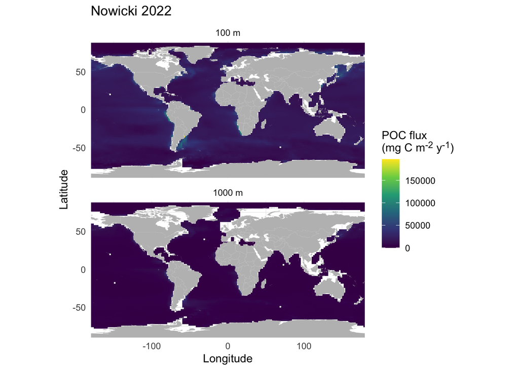

```r
## Read model output
nc_now_2022 <- nc_open("data/raw/biopump_model_output.nc")
nc_data_now_2022 <- nc_now_2022 %>%
  {list(
    lon = ncvar_get(., "LON")[1,,1],
    lat = ncvar_get(., "LAT")[,1,1],
    depth = ncvar_get(., "DEPTH")[1,1,],
    poc_flux = ncvar_get(., "POCflux") # mmolC/m^2/yr
  )}
# Close file
nc_close(nc_now_2022)
# To vector and to single column df
df_now_2022 <- nc_data_now_2022$poc_flux %>% as.vector() %>% as.data.frame() %>% setNames("poc_flux")
# Add lon, lat and depth
df_now_2022$lat <- nc_data_now_2022$lat # need to start with lat because of how data is stored
df_now_2022$lon <- rep(nc_data_now_2022$lon, each = length(nc_data_now_2022$lat))
df_now_2022$depth <- rep(nc_data_now_2022$depth, each = length(nc_data_now_2022$lon)*length(nc_data_now_2022$lat))
# Clean and reformat data
df_now_2022 <- df_now_2022 %>%
  as_tibble() %>%
  mutate(
    lon = ifelse(lon > 180, lon - 360, lon), # Center map on 0 longitude
    poc_flux = na_if(poc_flux, 0),  # Convert 0 to NA ,
    poc_flux = poc_flux * 12,       # Convert mmol m⁻² y⁻¹ to mgC m⁻² y⁻¹
    model = "Nowicki 2022"
  ) %>%
  filter(between(depth, 90, 100) | between(depth, 900, 1000)) %>%
  mutate(
    depth = case_when(
      depth < 100 ~ 100,
      depth > 100 ~ 1000
    )
  ) %>%
  select(lon, lat, depth, poc_flux, model) # Reorganize the final columns

# Plot to check
ggplot(df_now_2022) +
  geom_raster(aes(x = lon, y = lat, fill = poc_flux)) +
  geom_polygon(data = world, aes(x = lon, y = lat, group = group), fill = "grey") +
  scale_fill_viridis_c(na.value = NA) +
  labs(
    x = "Longitude", y = "Latitude",
    fill = "POC flux<br>(mg C m<sup>-2</sup> y<sup>-1</sup>)"
  ) +
  coord_quickmap(expand = 0) +
  facet_wrap(~depth, ncol = 1, labeller = labeller(depth = function(x) paste0(x, " m"))) +
  ggtitle("Nowicki 2022") +
  theme(legend.title = element_markdown())
```

## Compute pixel area

Pixel values are not round: use the same method as for Wang 2023. Grid is ~2°×2°, so we expect a maximal area of ~50000 km².

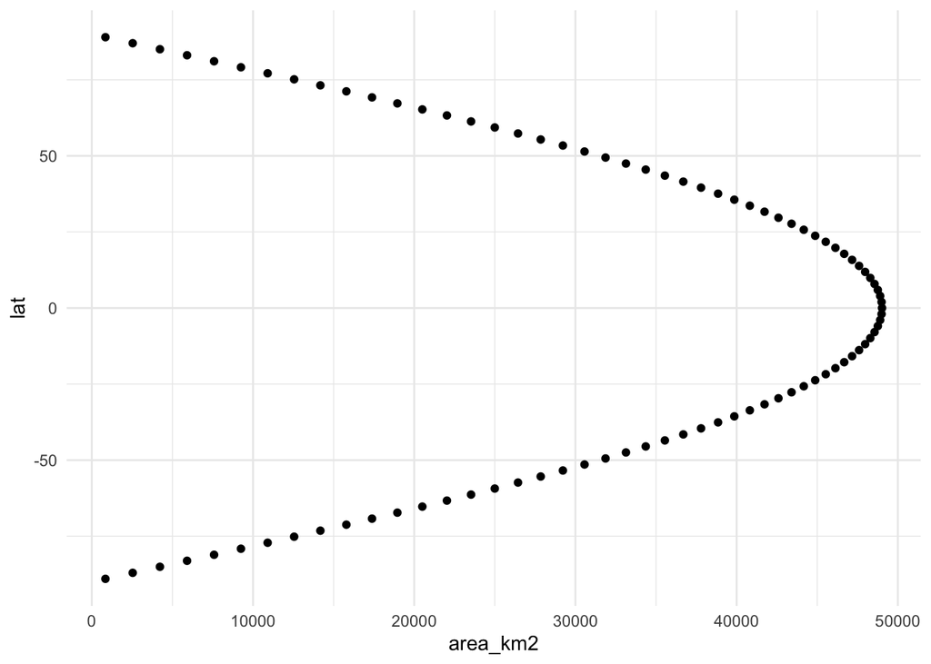

```r
pix_area <- df_now_2022 %>%
  select(lat) %>%
  distinct() %>%
  arrange(desc(lat)) %>%
  mutate(
    lag_lat = lag(lat),
    diff = lag_lat - lat,
    diff = ifelse(is.na(diff), median(diff, na.rm = TRUE), diff)
  ) %>%
  mutate(
    lat1 = (lat + (diff / 2)) * pi / 180, # upper border
    lat2 = (lat - (diff / 2)) * pi / 180, # lower border
    area_m2 = ((pi/180)*(R)^2 * abs(sin(lat1) - sin(lat2)))*10^6 * 2, # area in m² # *2 at the end because these are 2° pixels in longitude
    area_km2 = area_m2 / 1e6, # area in km²
  )

# Plot computed area VS latitude
ggplot(pix_area) +
  geom_point(aes(x = area_km2, y = lat))
```

## Compute integrated flux

```r
## Compute integrated POC flux
df_now_2022 <- df_now_2022 %>%
  left_join(pix_area %>% select(lat, area_m2, area_km2), by = join_by(lat)) %>%
  mutate(poc_flux_2 = poc_flux * area_m2)

# Group and sum by layer
res_now_2022 <- df_now_2022 %>%
  group_by(depth) %>%
  summarise(
    tot_poc_flux_mg = sum(poc_flux_2, na.rm = TRUE),
    tot_poc_flux_pg = tot_poc_flux_mg * 10^(-18)
  )
res_now_2022
```

```
# A tibble: 2 × 3
  depth tot_poc_flux_mg tot_poc_flux_pg
  <dbl>           <dbl>           <dbl>
1   100         6.56e18            6.56
2  1000         1.20e18            1.20
```

Computed fluxes are:

- **6.6 Pg C y⁻¹ at 100 m**
- **1.2 Pg C y⁻¹ at 1000 m**

Doney 2024 report the value of **6.4 Pg C y⁻¹ at 100 m.**

# Summary of results

| Source | Depth (m) | Computed (Pg C y⁻¹) | Expected (Pg C y⁻¹) |
| --- | --- | --- | --- |
| Wang 2023 | 73 | 10.8 | 10.6 |
| Wang 2023 | 100 | 7.4 | - |
| Wang 2023 | 1000 | 0.6 | - |
| DeVries and Weber 2022 | 100 | 6.1 | 6.1 |
| DeVries and Weber 2022 | 1000 | 0.9 | - |
| Nowicki 2022 | 100 | 6.6 | 6.4 |
| Nowicki 2022 | 1000 | 1.2 | - |